# Принятие решений в бизнесе на основе данных

Для увеличения выручки в крупном интернет-магазине вместе с отделом маркетинга мы подготовили список гипотез. Сделаем приоритизирию гипотез, запустим A/B-тест и проанализиуем результаты.

**Данные для первой части**

Файл */datasets/hypothesis.csv.* Скачать датасет

- **Hypothesis** — краткое описание гипотезы;
- **Reach** — охват пользователей по 10-балльной шкале;
- **Impact** — влияние на пользователей по 10-балльной шкале;
- **Confidence** — уверенность в гипотезе по 10-балльной шкале;
- **Efforts** — затраты ресурсов на проверку гипотезы по 10-балльной шкале. Чем больше значение Efforts, тем дороже проверка гипотезы.

**Данные для второй части**

Файл **/datasets/orders.csv.** Скачать датасет

- **transactionId** — идентификатор заказа;
- **visitorId** — идентификатор пользователя, совершившего заказ;
- **date** — дата, когда был совершён заказ;
- **revenue** — выручка заказа;
- **group** — группа A/B-теста, в которую попал заказ.

Файл */datasets/visitors.csv.* Скачать датасет

- **date** — дата;
- **group** — группа A/B-теста;
- **visitors** — количество пользователей в указанную дату в указанной группе A/B-теста

Подготовка данных к анализу

Загрузить данные из таблиц, провести первичный анализ Оптимизировать данные для анализа (поиск дублей, анализ пропусков, проверка названий столбцов и т.п.) Проверка/корректировка типов данных

```python
# импортируем необходимые библиотеки
import pandas as pd
import matplotlib.pyplot as plt
import math
import seaborn as sns
import scipy.stats as stats
import numpy as np
import datetime as dt

# для отображения в jupiter всех колонок и столбцов df + сокращу количество цифр после запятой
pd.set_option('display.max_columns', None)
pd.set_option('display.max_rows', None)
pd.set_option('display.precision',2)
```

```python
# загружаем данные о визитах, заказах и гипотезах из CSV-файлов в переменные.
try:
    visitors = pd.read_csv(r"B:\Downloads\ПРОЕКТ Спринт 13 А-В\visitors.csv", sep = ',') # информация о посещениях сайта

    orders = pd.read_csv(r"B:\Downloads\ПРОЕКТ Спринт 13 А-В\orders.csv", sep = ',') # информацию о заказах

    hypothesis = pd.read_csv(r"B:\Downloads\ПРОЕКТ Спринт 13 А-В\hypothesis.csv", sep = ',') # информацию о гипотезах

except:
    visitors = pd.read_csv("/datasets/visitors.csv", sep = ',')
    orders = pd.read_csv("/datasets/orders.csv", sep = ',')
    hypothesis = pd.read_csv("/datasets/hypothesis.csv", sep = ',')
```

```python
display(hypothesis.head())
display(hypothesis.info())
display(hypothesis.describe())
print('Количество дублей:', hypothesis.duplicated().sum())
```

|  | Hypothesis | Reach | Impact | Confidence | Efforts |
| --- | --- | --- | --- | --- | --- |
| 0 | Добавить два новых канала привлечения трафика,... | 3 | 10 | 8 | 6 |
| 1 | Запустить собственную службу доставки, что сок... | 2 | 5 | 4 | 10 |
| 2 | Добавить блоки рекомендаций товаров на сайт ин... | 8 | 3 | 7 | 3 |
| 3 | Изменить структура категорий, что увеличит кон... | 8 | 3 | 3 | 8 |
| 4 | Изменить цвет фона главной страницы, чтобы уве... | 3 | 1 | 1 | 1 |

```
<class 'pandas.core.frame.DataFrame'>
RangeIndex: 9 entries, 0 to 8
Data columns (total 5 columns):
 #   Column      Non-Null Count  Dtype
---  ------      --------------  -----
 0   Hypothesis  9 non-null      object
 1   Reach       9 non-null      int64
 2   Impact      9 non-null      int64
 3   Confidence  9 non-null      int64
 4   Efforts     9 non-null      int64
dtypes: int64(4), object(1)
memory usage: 488.0+ bytes
```

```
None
```

|  | Reach | Impact | Confidence | Efforts |
| --- | --- | --- | --- | --- |
| count | 9.00 | 9.00 | 9.00 | 9.00 |
| mean | 4.78 | 4.78 | 5.56 | 4.89 |
| std | 3.15 | 3.19 | 3.05 | 2.80 |
| min | 1.00 | 1.00 | 1.00 | 1.00 |
| 25% | 3.00 | 3.00 | 3.00 | 3.00 |
| 50% | 3.00 | 3.00 | 7.00 | 5.00 |
| 75% | 8.00 | 7.00 | 8.00 | 6.00 |
| max | 10.00 | 10.00 | 9.00 | 10.00 |

```
Количество дублей: 0
```

```python
# приводим название столбцов к нижнему регистру
hypothesis = hypothesis.rename(columns=lambda x: x.lower())
hypothesis.columns
```

```
Index(['hypothesis', 'reach', 'impact', 'confidence', 'efforts'], dtype='object')
```

```python
hypothesis
```

|  | hypothesis | reach | impact | confidence | efforts |
| --- | --- | --- | --- | --- | --- |
| 0 | Добавить два новых канала привлечения трафика,... | 3 | 10 | 8 | 6 |
| 1 | Запустить собственную службу доставки, что сок... | 2 | 5 | 4 | 10 |
| 2 | Добавить блоки рекомендаций товаров на сайт ин... | 8 | 3 | 7 | 3 |
| 3 | Изменить структура категорий, что увеличит кон... | 8 | 3 | 3 | 8 |
| 4 | Изменить цвет фона главной страницы, чтобы уве... | 3 | 1 | 1 | 1 |
| 5 | Добавить страницу отзывов клиентов о магазине,... | 3 | 2 | 2 | 3 |
| 6 | Показать на главной странице баннеры с актуаль... | 5 | 3 | 8 | 3 |
| 7 | Добавить форму подписки на все основные страни... | 10 | 7 | 8 | 5 |
| 8 | Запустить акцию, дающую скидку на товар в день... | 1 | 9 | 9 | 5 |

```python
display(orders.head())
display(orders.info())
display(orders.describe())
print('Количество дублей:', orders.duplicated().sum())
```

|  | transactionId | visitorId | date | revenue | group |
| --- | --- | --- | --- | --- | --- |
| 0 | 3667963787 | 3312258926 | 2019-08-15 | 1650 | B |
| 1 | 2804400009 | 3642806036 | 2019-08-15 | 730 | B |
| 2 | 2961555356 | 4069496402 | 2019-08-15 | 400 | A |
| 3 | 3797467345 | 1196621759 | 2019-08-15 | 9759 | B |
| 4 | 2282983706 | 2322279887 | 2019-08-15 | 2308 | B |

```
<class 'pandas.core.frame.DataFrame'>
RangeIndex: 1197 entries, 0 to 1196
Data columns (total 5 columns):
 #   Column         Non-Null Count  Dtype
---  ------         --------------  -----
 0   transactionId  1197 non-null   int64
 1   visitorId      1197 non-null   int64
 2   date           1197 non-null   object
 3   revenue        1197 non-null   int64
 4   group          1197 non-null   object
dtypes: int64(3), object(2)
memory usage: 46.9+ KB
```

```
None
```

|  | transactionId | visitorId | revenue |
| --- | --- | --- | --- |
| count | 1.20e+03 | 1.20e+03 | 1.20e+03 |
| mean | 2.16e+09 | 2.17e+09 | 8.35e+03 |
| std | 1.23e+09 | 1.24e+09 | 3.92e+04 |
| min | 1.06e+06 | 5.11e+06 | 5.00e+01 |
| 25% | 1.17e+09 | 1.11e+09 | 1.22e+03 |
| 50% | 2.15e+09 | 2.22e+09 | 2.98e+03 |
| 75% | 3.24e+09 | 3.18e+09 | 8.29e+03 |
| max | 4.29e+09 | 4.28e+09 | 1.29e+06 |

```
Количество дублей: 0
```

```python
display(visitors.head())
display(visitors.info())
display(visitors.describe())
print('Количество дублей:', visitors.duplicated().sum())
```

|  | date | group | visitors |
| --- | --- | --- | --- |
| 0 | 2019-08-01 | A | 719 |
| 1 | 2019-08-02 | A | 619 |
| 2 | 2019-08-03 | A | 507 |
| 3 | 2019-08-04 | A | 717 |
| 4 | 2019-08-05 | A | 756 |

```
<class 'pandas.core.frame.DataFrame'>
RangeIndex: 62 entries, 0 to 61
Data columns (total 3 columns):
 #   Column    Non-Null Count  Dtype
---  ------    --------------  -----
 0   date      62 non-null     object
 1   group     62 non-null     object
 2   visitors  62 non-null     int64
dtypes: int64(1), object(2)
memory usage: 1.6+ KB
```

```
None
```

|  | visitors |
| --- | --- |
| count | 62.00 |
| mean | 607.29 |
| std | 114.40 |
| min | 361.00 |
| 25% | 534.00 |
| 50% | 624.50 |
| 75% | 710.50 |
| max | 770.00 |

```
Количество дублей: 0
```

```python
# меняем формат стоблца date
for table in [visitors, orders]:
    table['date'] = table['date'].map(lambda x: dt.datetime.strptime(x, '%Y-%m-%d'))
```

```python
display(orders.info())
visitors.info()
```

```
<class 'pandas.core.frame.DataFrame'>
RangeIndex: 1197 entries, 0 to 1196
Data columns (total 5 columns):
 #   Column         Non-Null Count  Dtype
---  ------         --------------  -----
 0   transactionId  1197 non-null   int64
 1   visitorId      1197 non-null   int64
 2   date           1197 non-null   datetime64[ns]
 3   revenue        1197 non-null   int64
 4   group          1197 non-null   object
dtypes: datetime64[ns](1), int64(3), object(1)
memory usage: 46.9+ KB
```

```
None
```

```
<class 'pandas.core.frame.DataFrame'>
RangeIndex: 62 entries, 0 to 61
Data columns (total 3 columns):
 #   Column    Non-Null Count  Dtype
---  ------    --------------  -----
 0   date      62 non-null     datetime64[ns]
 1   group     62 non-null     object
 2   visitors  62 non-null     int64
dtypes: datetime64[ns](1), int64(1), object(1)
memory usage: 1.6+ KB
```

Данные загружены и подготовлены. Преобразовали в таблицах visitors и orders тип данных, сменили регистра названий колонок в таблице hypothesis и проверили таблицы на дубликкаты.

## Часть. Приоритизация гипотез.

В файле hypothesis.csv 9 гипотез по увеличению выручки интернет-магазина с указанными параметрами Reach, Impact, Confidence, Effort. Задача

1. Примените фреймворк ICE для приоритизации гипотез. Отсортируйте их по убыванию приоритета.
2. Примените фреймворк RICE для приоритизации гипотез. Отсортируйте их по убыванию приоритета.
3. Укажите, как изменилась приоритизация гипотез при применении RICE вместо ICE. Объясните, почему так произошло.

### Примените фреймворк ICE для приоритизации гипотез. Отсортируйте их по убыванию приоритета.

```python
hypothesis['ICE'] = hypothesis['impact'] * hypothesis['confidence'] / hypothesis['efforts']
print(hypothesis[['hypothesis', 'ICE']].sort_values(by='ICE', ascending=False))
```

```
                                          hypothesis    ICE
8  Запустить акцию, дающую скидку на товар в день...  16.20
0  Добавить два новых канала привлечения трафика,...  13.33
7  Добавить форму подписки на все основные страни...  11.20
6  Показать на главной странице баннеры с актуаль...   8.00
2  Добавить блоки рекомендаций товаров на сайт ин...   7.00
1  Запустить собственную службу доставки, что сок...   2.00
5  Добавить страницу отзывов клиентов о магазине,...   1.33
3  Изменить структура категорий, что увеличит кон...   1.12
4  Изменить цвет фона главной страницы, чтобы уве...   1.00
```

При приоритизации гипотез фреймворк ICE лидируют гипотезы: 8, 0 и 7.

### Примените фреймворк RICE для приоритизации гипотез. Отсортируйте их по убыванию приоритета.

```python
hypothesis['RICE'] = hypothesis['reach'] * hypothesis['impact'] * hypothesis['confidence'] / hypothesis['efforts']
print(hypothesis[['hypothesis', 'RICE']].sort_values(by='RICE', ascending=False))
```

```
                                          hypothesis   RICE
7  Добавить форму подписки на все основные страни...  112.0
2  Добавить блоки рекомендаций товаров на сайт ин...   56.0
0  Добавить два новых канала привлечения трафика,...   40.0
6  Показать на главной странице баннеры с актуаль...   40.0
8  Запустить акцию, дающую скидку на товар в день...   16.2
3  Изменить структура категорий, что увеличит кон...    9.0
1  Запустить собственную службу доставки, что сок...    4.0
5  Добавить страницу отзывов клиентов о магазине,...    4.0
4  Изменить цвет фона главной страницы, чтобы уве...    3.0
```

При приоритизации гипотез фреймворк RICE лидируют гипотезы: 7, 2 и 0, б.

### Укажите, как изменилась приоритизация гипотез при применении RICE вместо ICE. Объясните, почему так произошло.

```python
hypothesis
```

|  | hypothesis | reach | impact | confidence | efforts | ICE | RICE |
| --- | --- | --- | --- | --- | --- | --- | --- |
| 0 | Добавить два новых канала привлечения трафика,... | 3 | 10 | 8 | 6 | 13.33 | 40.0 |
| 1 | Запустить собственную службу доставки, что сок... | 2 | 5 | 4 | 10 | 2.00 | 4.0 |
| 2 | Добавить блоки рекомендаций товаров на сайт ин... | 8 | 3 | 7 | 3 | 7.00 | 56.0 |
| 3 | Изменить структура категорий, что увеличит кон... | 8 | 3 | 3 | 8 | 1.12 | 9.0 |
| 4 | Изменить цвет фона главной страницы, чтобы уве... | 3 | 1 | 1 | 1 | 1.00 | 3.0 |
| 5 | Добавить страницу отзывов клиентов о магазине,... | 3 | 2 | 2 | 3 | 1.33 | 4.0 |
| 6 | Показать на главной странице баннеры с актуаль... | 5 | 3 | 8 | 3 | 8.00 | 40.0 |
| 7 | Добавить форму подписки на все основные страни... | 10 | 7 | 8 | 5 | 11.20 | 112.0 |
| 8 | Запустить акцию, дающую скидку на товар в день... | 1 | 9 | 9 | 5 | 16.20 | 16.2 |

На изменения приоритизации гипотез при применении RICE вместо ICE повлияло количество охвата пользователей. На первом месте при применении ICE(16.200000) была 8 гипотиза (Запустить акцию, дающую скидку на товар в день...), но данная гипотиза reach (охват пользователей) составляет 1, поэтому эта гипотиза при применении RICE(16.2) ушла на 5 место. Тоже самое произошло с гипотизой 0 (Добавить два новых канала привлечения трафика,...). При применении ICE(13.333333) у 0 гипотизы не учитывается reach (охват пользователей) составляет 3, поэтому эта гипотиза при применении RICE(40.0) ушла со 2 на 3 место.

Наиболее перспективная гипотез - 7(Добавить форму подписки на все основные страни...). При применении ICE(11.200000) 7 гипотиза была на 3 месте, а при применении RICE(112.0) вышла в лидеры, заняла первое место(reach составляет 10). Потому что кроме силы гипотез необходимо учитывать и то, как много пользователей она затронет.

## Часть. Анализ A/B-теста

Вы провели A/B-тест и получили результаты, которые описаны в файлах orders.csv и visitors.csv.

Задача Проанализируйте A/B-тест:

1. Постройте график кумулятивной выручки по группам. Сделайте выводы и предположения.
2. Постройте график кумулятивного среднего чека по группам. Сделайте выводы и предположения.
3. Постройте график относительного изменения кумулятивного среднего чека группы B к группе A. Сделайте выводы и предположения.
4. Постройте график кумулятивного среднего количества заказов на посетителя по группам. Сделайте выводы и предположения.
5. Постройте график относительного изменения кумулятивного среднего количества заказов на посетителя группы B к группе A. Сделайте выводы и предположения.
6. Постройте точечный график количества заказов по пользователям. Сделайте выводы и предположения.
7. Посчитайте 95-й и 99-й перцентили количества заказов на пользователя. Выберите границу для определения аномальных пользователей.
8. Постройте точечный график стоимостей заказов. Сделайте выводы и предположения.
9. Посчитайте 95-й и 99-й перцентили стоимости заказов. Выберите границу для определения аномальных заказов.
10. Посчитайте статистическую значимость различий в среднем количестве заказов на посетителя между группами между группами по «сырым» данным. Сделайте выводы и предположения.
11. Посчитайте статистическую значимость различий в среднем чеке заказа между группами по «сырым» данным. Сделайте выводы и предположения.
12. Посчитайте статистическую значимость различий в среднем количестве заказов на посетителя между группами между группами по «очищенным» данным. Сделайте выводы и предположения.
13. Посчитайте статистическую значимость различий в среднем чеке заказа между группами по «очищенным» данным. Сделайте выводы и предположения.
14. Примите решение по результатам теста и объясните его. Варианты решений: 1. Остановить тест, зафиксировать победу одной из групп. 2. Остановить тест, зафиксировать отсутствие различий между группами. 3. Продолжить тест.

Предварительно изучим количество заказов и посещений в каждой из групп.

```python
print ('Количество посещений в группе А -', visitors.query('group == "A"')['visitors'].sum())
print ('Количество посещений в группе B -',visitors.query('group == "B"')['visitors'].sum())
print('-----------------------------------')
print ('Количество заказов в группе А -', orders.query('group == "A"').shape[0])
print ('Количество заказов в группе B -',orders.query('group == "B"').shape[0])
```

```
Количество посещений в группе А - 18736
Количество посещений в группе B - 18916
-----------------------------------
Количество заказов в группе А - 557
Количество заказов в группе B - 640
```

В группе В на 180 посещений больше, чем в группе А. Проверим пересечение пользователей между группами.

```python
# пересечение пользователей между группами
visitors_a = set(orders[orders["group"] == "A"]["visitorId"].unique())
visitors_b = set(orders[orders["group"] == "B"]["visitorId"].unique())
visitors_ab = visitors_a.intersection(visitors_b)
print(f'Количество пересекающихся пользователей между группами A и B: {len(visitors_ab)}')
```

```
Количество пересекающихся пользователей между группами A и B: 58
```

```python
# удаляем количество пересекающихся пользователей между группами A и B
orders = orders[~orders["visitorId"].isin(visitors_ab)]
```

```python
# проверяем пересечение пользователей между группами
visitors_a = set(orders[orders["group"] == "A"]["visitorId"].unique())
visitors_b = set(orders[orders["group"] == "B"]["visitorId"].unique())
visitors_ab = visitors_a.intersection(visitors_b)
print(f'Количество пересекающихся пользователей между группами A и B: {len(visitors_ab)}')
```

```
Количество пересекающихся пользователей между группами A и B: 0
```

```python
print ('Количество заказов в группе А -', orders.query('group == "A"').shape[0])
print ('Количество заказов в группе B -',orders.query('group == "B"').shape[0])
```

```
Количество заказов в группе А - 468
Количество заказов в группе B - 548
```

Количество заказов в группе А уменьшилось на 89(557-468), в группе В на 92(640-548).

### Постройте график кумулятивной выручки по группам. Сделайте выводы и предположения.

```python
# создаем массив уникальных пар значений дат и групп теста
datesGroups = orders[['date','group']].drop_duplicates()

# получаем агрегированные кумулятивные по дням данные о заказах
ordersAggregated = datesGroups.apply(lambda x: orders[np.logical_and(orders['date'] <= x['date'], orders['group'] == x['group'])].agg({'date' : 'max', 'group' : 'max', 'transactionId' : 'nunique', 'visitorId' : 'nunique', 'revenue' : 'sum'}), axis=1).sort_values(by=['date','group'])

# получаем агрегированные кумулятивные по дням данные о посетителях интернет-магазина
visitorsAggregated = datesGroups.apply(lambda x: visitors[np.logical_and(visitors['date'] <= x['date'], visitors['group'] == x['group'])].agg({'date' : 'max', 'group' : 'max', 'visitors' : 'sum'}), axis=1).sort_values(by=['date','group'])

# объединяем кумулятивные данные в одной таблице и присваиваем ее столбцам понятные названия
cumulativeData = ordersAggregated.merge(visitorsAggregated, left_on=['date', 'group'], right_on=['date', 'group'])
cumulativeData.columns = ['date', 'group', 'orders', 'buyers', 'revenue', 'visitors']

print(cumulativeData.head(5))
```

```
        date group  orders  buyers  revenue  visitors
0 2019-08-01     A      23      19   142779       719
1 2019-08-01     B      17      17    59758       713
2 2019-08-02     A      42      36   234381      1338
3 2019-08-02     B      40      39   221801      1294
4 2019-08-03     A      66      60   346854      1845
```

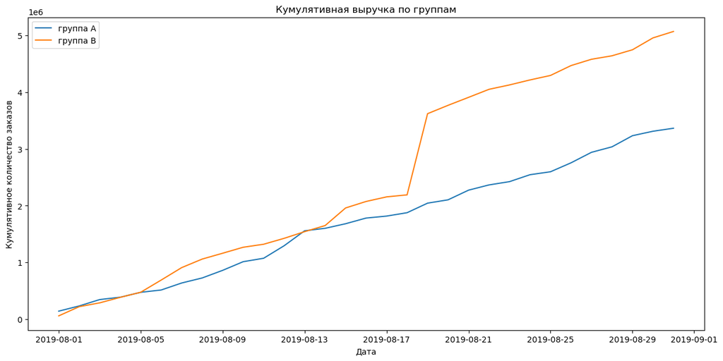

```python
# датафрейм с кумулятивным количеством заказов и кумулятивной выручкой по дням в группе А
cumulativeRevenueA = cumulativeData[cumulativeData['group']=='A'][['date','revenue', 'orders']]

# датафрейм с кумулятивным количеством заказов и кумулятивной выручкой по дням в группе B
cumulativeRevenueB = cumulativeData[cumulativeData['group']=='B'][['date','revenue', 'orders']]

# размер графика
plt.figure(figsize=(15, 7))
# Строим график выручки группы А
plt.plot(cumulativeRevenueA['date'], cumulativeRevenueA['revenue'], label='A')

# Строим график выручки группы B
plt.plot(cumulativeRevenueB['date'], cumulativeRevenueB['revenue'], label='B')

# подписываем названия графика, оси и легенд
plt.title('Кумулятивная выручка по группам')
plt.xlabel("Дата")
plt.ylabel("Кумулятивное количество заказов")
plt.legend(['группа A','группа B']);
```

Выручка почти равномерно увеличивается в течение всего теста. Хороший знак. Однако на графике выручка в группе В есть резкий скачек 18-19 августа. Это может сигнализировать о всплесках числа заказов, либо о появлении очень дорогих заказов в выборке.

### Постройте график кумулятивного среднего чека по группам. Сделайте выводы и предположения.

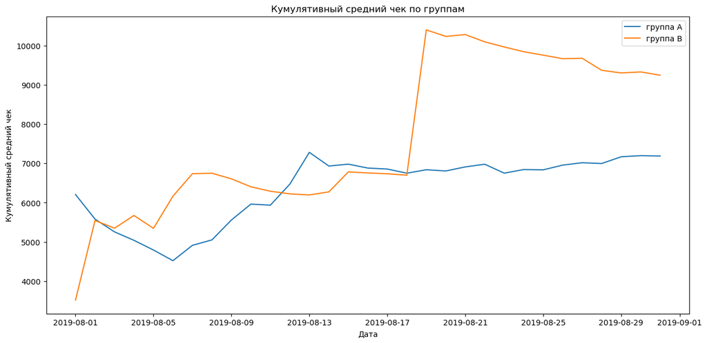

```python
# размер графика
plt.figure(figsize=(15, 7))

# строим график среднего чека группы А
plt.plot(cumulativeRevenueA['date'], cumulativeRevenueA['revenue']/cumulativeRevenueA['orders'], label='A')

# строим график среднего чека группы В
plt.plot(cumulativeRevenueB['date'], cumulativeRevenueB['revenue']/cumulativeRevenueB['orders'], label='B')

# подписываем названия графика, оси и легенд
plt.title('Кумулятивный средний чек по группам')
plt.xlabel("Дата")
plt.ylabel("Кумулятивный средний чек")
plt.legend(['группа A','группа B']);
```

Средний чек обеих групп выравнивается после 13 августа. Однако, в очередной раз видим, что в группу В попали крупные заказы 18-19 августа и после чего средний чек этой группы начинает снижаться. Тогда ей нужно больше данных, чтобы прийти к реальному среднему чеку и установиться на его уровне.

### Постройте график относительного изменения кумулятивного среднего чека группы B к группе A. Сделайте выводы и предположения.

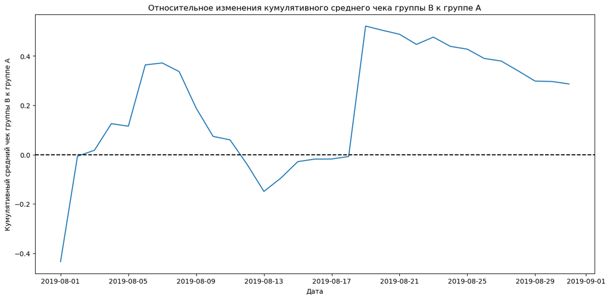

```python
# построим график относительного различия для среднего чека. Добавим горизонтальную ось методом axhline()

# собираем данные в одном датафрейме
mergedCumulativeRevenue = cumulativeRevenueA.merge(cumulativeRevenueB, left_on='date', right_on='date', how='left', suffixes=['A', 'B'])

# размер графика
plt.figure(figsize=(15, 7))

# cтроим отношение средних чеков группы B к группе A
plt.plot(mergedCumulativeRevenue['date'], (mergedCumulativeRevenue['revenueB']/mergedCumulativeRevenue['ordersB'])/(mergedCumulativeRevenue['revenueA']/mergedCumulativeRevenue['ordersA'])-1)

# подписываем оси и названия графика
plt.title('Относительное изменения кумулятивного среднего чека группы B к группе A')
plt.xlabel("Дата")
plt.ylabel("Кумулятивный средний чек группы B к группе A")

# добавляем ось X
plt.axhline(y=0, color='black', linestyle='--');
```

Средний чек группы В в начале теста был ниже группы А, но в концу теста он намного опередил группу А. В нескольких точках график различия между сегментами резко «скачет». Где-то уж точно спрятались крупные заказы и выбросы!

### Постройте график кумулятивного среднего количества заказов на посетителя по группам. Сделайте выводы и предположения.

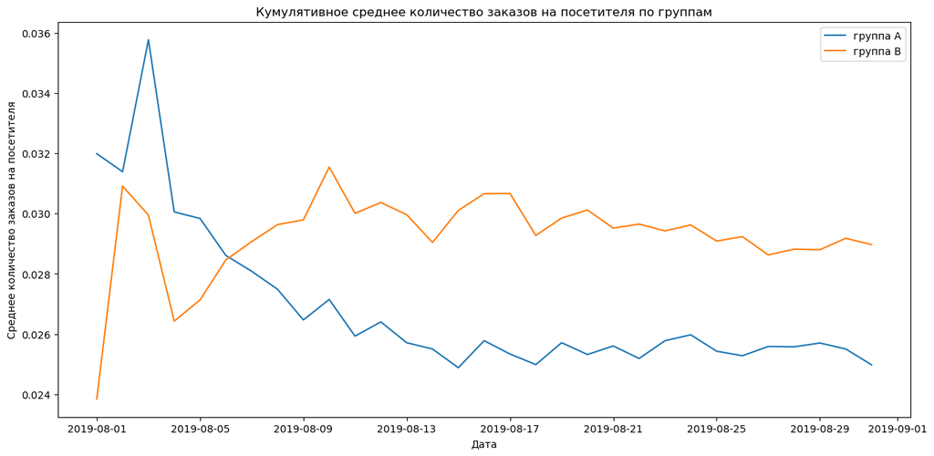

```python
# датафрейм с кумулятивным количеством заказов на посетителя группе А
cumulativeVisitorsA = cumulativeData[cumulativeData['group']=='A'][['date','visitors', 'orders']]

# датафрейм с кумулятивным количеством заказов на посетителя группе B
cumulativeVisitorsB = cumulativeData[cumulativeData['group']=='B'][['date','visitors', 'orders']]

# размер графика
plt.figure(figsize=(15, 7))

# строим график среднего количества заказов на посетителя группы А
plt.plot(cumulativeVisitorsA['date'], cumulativeVisitorsA['orders']/cumulativeVisitorsA['visitors'], label='A')

# строим график среднего количества заказов на посетителя группы B
plt.plot(cumulativeVisitorsB['date'], cumulativeVisitorsB['orders']/cumulativeVisitorsB['visitors'], label='B')

# подписываем названия графика, оси и легенд
plt.title('Кумулятивное среднее количество заказов на посетителя по группам')
plt.xlabel("Дата")
plt.ylabel("Среднее количество заказов на посетителя")
plt.legend(['группа A','группа B']);
```

Получился интересный результат, на первых этапах кумулятивное среднее количество заказов на посетителя в обеих группах "прыгала". После 6 августа группа В выбилась в лидеры и концу августа зафиксировалась. Группа А до 15 августа резко снижалась и концу августа зафиксировалась.

### Постройте график относительного изменения кумулятивного среднего количества заказов на посетителя группы B к группе A. Сделайте выводы и предположения.

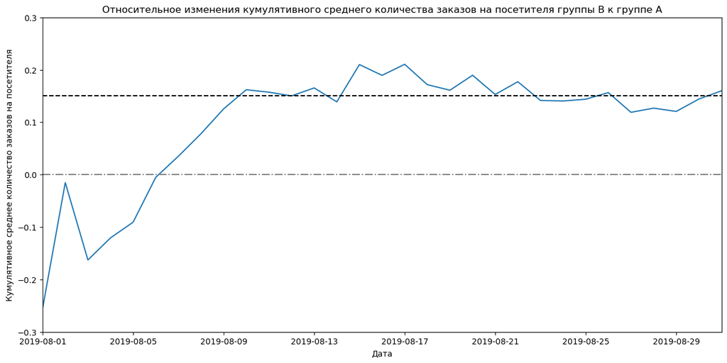

```python
# собираем данные в одном датафрейме
mergedCumulativeVisitors = cumulativeVisitorsA.merge(cumulativeVisitorsB, left_on='date', right_on='date', how='left', suffixes=['A', 'B'])

# размер графика
plt.figure(figsize=(15, 7))

# cтроим отношение среднего количества заказов на посетителя группы B к группе A
plt.plot(mergedCumulativeVisitors['date'], (mergedCumulativeVisitors['ordersB']/mergedCumulativeVisitors['visitorsB'])/(mergedCumulativeVisitors['ordersA']/mergedCumulativeVisitors['visitorsA'])-1)

# подписываем названия графика, оси и легенд
plt.title('Относительное изменения кумулятивного среднего количества заказов на посетителя группы B к группе A')
plt.xlabel("Дата")
plt.ylabel("Кумулятивное среднее количество заказов на посетителя")
plt.axis(xmin=mergedCumulativeVisitors['date'].min(), xmax=mergedCumulativeVisitors['date'].max(), ymin=-0.30, ymax=0.3)
plt.axhline(y=0, color='grey', linestyle='-.')
plt.axhline(y=0.15, color='black', linestyle='--');
```

Группа B брала разгон в начале теста, и теперь стабильно и существенно обгоняет группу А.

### Постройте точечный график количества заказов по пользователям. Сделайте выводы и предположения.

```python
# подсчитаем количество заказов по пользователям
ordersByUsers = (
    orders.groupby('visitorId', as_index=False)
    .agg({'transactionId': 'nunique'})
)

ordersByUsers.columns = ['userId', 'orders']

ordersByUsers.sort_values(by='orders', ascending=False).head(10)
```

|  | userId | orders |
| --- | --- | --- |
| 908 | 3967698036 | 3 |
| 55 | 249864742 | 3 |
| 478 | 2108163459 | 3 |
| 687 | 2988190573 | 3 |
| 890 | 3908431265 | 3 |
| 138 | 611059232 | 3 |
| 632 | 2742574263 | 3 |
| 157 | 678354126 | 2 |
| 323 | 1404560065 | 2 |
| 452 | 1985475298 | 2 |

```python
c = ordersByUsers.groupby('orders')['userId'].count()
c
```

```
orders
1    937
2     29
3      7
Name: userId, dtype: int64
```

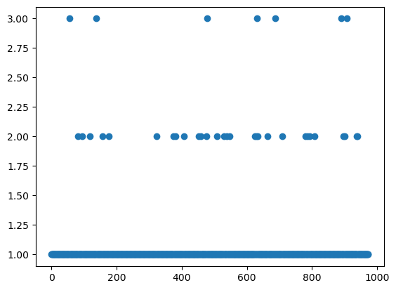

```python
x_values = pd.Series(range(0,len(ordersByUsers)))

plt.scatter(x_values, ordersByUsers['orders']);
```

В основном пользователи заказывали один раз. Есть пользователи с 2-3 заказами. Их точная доля не ясна — непонятно, считать их аномалиями или нет.

### Посчитайте 95-й и 99-й перцентили количества заказов на пользователя. Выберите границу для определения аномальных пользователей.

```python
print(np.percentile(ordersByUsers['orders'], [95, 99]))
top_orders =np.percentile(ordersByUsers['orders'], 95)
```

```
[1. 2.]
```

Не более 5% пользователей совершали больше одного заказа. И не более 1% пользователей — больше двух заказов.

### Постройте точечный график стоимостей заказов. Сделайте выводы и предположения.

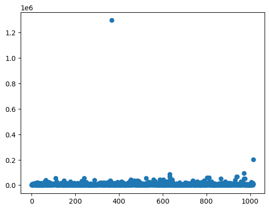

```python
# строим точечный график стоимостей заказов
x_values = pd.Series(range(0,len(orders['revenue'])))
plt.scatter(x_values, orders['revenue']);
```

Заказы свыше 100 000 рублей встречаются два раза. Самый большой заказ на сумму свыше 1.2 миллиона рублей.

### Посчитайте 95-й и 99-й перцентили стоимости заказов. Выберите границу для определения аномальных заказов.

```python
print(np.percentile(orders['revenue'], [95, 99]))
top_revenue =np.percentile(orders['revenue'], 95)
```

```
[26785. 53904.]
```

Не более, чем у 5% заказов чек дороже 26 785 рублей. И не больше, чем у 1% заказов - дороже 53 904 рублей.

### Посчитайте статистическую значимость различий в среднем количестве заказов на посетителя между группами по «сырым» данным. Сделайте выводы и предположения.

Сформулируем гипотезы.

Нулевая: различий в среднем количестве заказов между группами нет.

Альтернативная: различия в среднем между группами есть.

Примем для себя уровень значимости alpha = 0.05

```python
# начнём с подготовки данных. Изучиим код и устройство таблицы data:
visitorsADaily = visitors[visitors['group'] == 'A'][['date', 'visitors']]
visitorsADaily.columns = ['date', 'visitorsPerDateA']

visitorsACummulative = visitorsADaily.apply(
    lambda x: visitorsADaily[visitorsADaily['date'] <= x['date']].agg(
        {'date': 'max', 'visitorsPerDateA': 'sum'}
    ),
    axis=1,
)
visitorsACummulative.columns = ['date', 'visitorsCummulativeA']

visitorsBDaily = visitors[visitors['group'] == 'B'][['date', 'visitors']]
visitorsBDaily.columns = ['date', 'visitorsPerDateB']

visitorsBCummulative = visitorsBDaily.apply(
    lambda x: visitorsBDaily[visitorsBDaily['date'] <= x['date']].agg(
        {'date': 'max', 'visitorsPerDateB': 'sum'}
    ),
    axis=1,
)
visitorsBCummulative.columns = ['date', 'visitorsCummulativeB']

ordersADaily = (
    orders[orders['group'] == 'A'][['date', 'transactionId', 'visitorId', 'revenue']]
    .groupby('date', as_index=False)
    .agg({'transactionId': pd.Series.nunique, 'revenue': 'sum'})
)
ordersADaily.columns = ['date', 'ordersPerDateA', 'revenuePerDateA']

ordersACummulative = ordersADaily.apply(
    lambda x: ordersADaily[ordersADaily['date'] <= x['date']].agg(
        {'date': 'max', 'ordersPerDateA': 'sum', 'revenuePerDateA': 'sum'}
    ),
    axis=1,
).sort_values(by=['date'])
ordersACummulative.columns = [
    'date',
    'ordersCummulativeA',
    'revenueCummulativeA',
]

ordersBDaily = (
    orders[orders['group'] == 'B'][['date', 'transactionId', 'visitorId', 'revenue']]
    .groupby('date', as_index=False)
    .agg({'transactionId': pd.Series.nunique, 'revenue': 'sum'})
)
ordersBDaily.columns = ['date', 'ordersPerDateB', 'revenuePerDateB']

ordersBCummulative = ordersBDaily.apply(
    lambda x: ordersBDaily[ordersBDaily['date'] <= x['date']].agg(
        {'date': 'max', 'ordersPerDateB': 'sum', 'revenuePerDateB': 'sum'}
    ),
    axis=1,
).sort_values(by=['date'])
ordersBCummulative.columns = [
    'date',
    'ordersCummulativeB',
    'revenueCummulativeB',
]

data = (
    ordersADaily.merge(
        ordersBDaily, left_on='date', right_on='date', how='left'
    )
    .merge(ordersACummulative, left_on='date', right_on='date', how='left')
    .merge(ordersBCummulative, left_on='date', right_on='date', how='left')
    .merge(visitorsADaily, left_on='date', right_on='date', how='left')
    .merge(visitorsBDaily, left_on='date', right_on='date', how='left')
    .merge(visitorsACummulative, left_on='date', right_on='date', how='left')
    .merge(visitorsBCummulative, left_on='date', right_on='date', how='left')
)
print(data)
```

```
         date  ordersPerDateA  revenuePerDateA  ordersPerDateB  \
0  2019-08-01              23           142779              17
1  2019-08-02              19            91602              23
2  2019-08-03              24           112473              14
3  2019-08-04              11            41176              14
4  2019-08-05              22            86383              21
5  2019-08-06              15            40919              23
6  2019-08-07              16           123248              23
7  2019-08-08              14            88639              22
8  2019-08-09              11           134237              19
9  2019-08-10              15           152275              22
10 2019-08-11              11            60665              12
11 2019-08-12              19           220392              19
12 2019-08-13              14           263638              20
13 2019-08-14              17            43266              14
```

[output cut: 116 more lines]

```python
# создадим переменные ordersByUsersA и ordersByUsersB со столбцами ['userId', 'orders'].
# В них для пользователей, которые заказывали хотя бы 1 раз, укажем число совершённых заказов.
ordersByUsersA = (
    orders[orders['group'] == 'A']
    .groupby('visitorId', as_index=False)
    .agg({'transactionId': pd.Series.nunique})
)
ordersByUsersA.columns = ['userId', 'orders']

ordersByUsersB = (
    orders[orders['group'] == 'B']
    .groupby('visitorId', as_index=False)
    .agg({'transactionId': pd.Series.nunique})
)
ordersByUsersB.columns = ['userId', 'orders']

# объявим переменные sampleA и sampleB, в которых пользователям с заказами будет соответствовать число заказов пользователя. А пользователям без заказов — нули.
sampleA = pd.concat([ordersByUsersA['orders'],pd.Series(0, index=np.arange(data['visitorsPerDateA'].sum() - len(ordersByUsersA['orders'])), name='orders')],axis=0)

sampleB = pd.concat([ordersByUsersB['orders'],pd.Series(0, index=np.arange(data['visitorsPerDateB'].sum() - len(ordersByUsersB['orders'])), name='orders')],axis=0)

# считаем статистическую значимость различия среднего количества заказов по результатам двух недель теста.
# применим тест Манна-Уитни
print("p_value: {0:.3f}".format(stats.mannwhitneyu(sampleA, sampleB)[1]))

print("{0:.3f}".format(sampleB.mean() / sampleA.mean() - 1))
```

```
p_value: 0.011
0.160
```

Вывод: По «сырым» p-value = 0.011 меньше 0.05. Значит, нулевую гипотезу о том, что статистически значимых различий в среднем числе заказов между группами нет, отвергаем. Относительный проигрыш группы А равен 16%.

### Посчитайте статистическую значимость различий в среднем чеке заказа между группами по «сырым» данным. Сделайте выводы и предположения.

Сформулируем гипотизу:

Нулевая гипотеза: различий в среднем чеке между группами нет.

Альтернативная гипотеза: различия в среднем чеке между группами есть.

Примем для себя уровень значимости alpha = 0.05

```python
# посчитаем статистическую значимость различия средних чеков между группами
print('p_value:{0:.3f}'.format(stats.mannwhitneyu(orders[orders['group']=='A']['revenue'], orders[orders['group']=='B']['revenue'])[1]))
print('{0:.3f}'.format(orders[orders['group']=='B']['revenue'].mean()/orders[orders['group']=='A']['revenue'].mean()-1))
print('Средний чек группы А: {:.2f}'.format(orders[orders['group']=='A']['revenue'].mean()))
print('Средний чек группы B: {:.2f}'.format(orders[orders['group']=='B']['revenue'].mean()))
```

```
p_value:0.829
0.287
Средний чек группы А: 7189.44
Средний чек группы B: 9249.95
```

Вывод: По «сырым» p-value=0.829,значительно больше 0.05. Значит, причин отвергать нулевую гипотезу и считать, что в среднем чеке есть различия, нет. Впрочем, средний чек группы B значительно выше среднего чека группы A на 28.7%.

### Посчитайте статистическую значимость различий в среднем количестве заказов на посетителя между группами между группами по «очищенным» данным. Сделайте выводы и предположения.

Примем за аномальных пользователей тех, кто совершил больше 1 заказа или совершил заказ дороже 26 785 рублей.

Сформулируем гипотезы.

Нулевая: различий в среднем количестве заказов между группами нет.

Альтернативная: различия в среднем между группами есть.

Примем для себя уровень значимости alpha = 0.05

```python
# cделаем срезы пользователей с числом заказов больше 1 — usersWithManyOrders и пользователей, совершивших заказы дороже 30 000 — usersWithExpensiveOrders. Объединим их в таблице abnormalUsers.
usersWithManyOrders = pd.concat(
    [
        ordersByUsersA[ordersByUsersA['orders'] > top_orders]['userId'],
        ordersByUsersB[ordersByUsersB['orders'] > top_orders]['userId'],
    ],
    axis=0,
)
usersWithExpensiveOrders = orders[orders['revenue'] >= top_revenue]['visitorId']
abnormalUsers = (
    pd.concat([usersWithManyOrders, usersWithExpensiveOrders], axis=0)
    .drop_duplicates()
    .sort_values()
)
print(abnormalUsers.head(5))
print(abnormalUsers.shape[0])
```

```
568     113298937
1099    148427295
928     204675465
33      249864742
684     358944393
dtype: int64
86
```

Всего 86 аномальных пользователей.

```python
# подготовим выборки количества заказов по пользователям по группам теста:
sampleAFiltered = pd.concat([ordersByUsersA[np.logical_not(ordersByUsersA['userId'].isin(abnormalUsers))]['orders'],
        pd.Series(0,index=np.arange(data['visitorsPerDateA'].sum() - len(ordersByUsersA['orders'])),name='orders',),],axis=0)

sampleBFiltered = pd.concat([ordersByUsersB[np.logical_not(ordersByUsersB['userId'].isin(abnormalUsers))]['orders'],
        pd.Series(0,index=np.arange(data['visitorsPerDateB'].sum() - len(ordersByUsersB['orders'])),name='orders',),],axis=0)

# применим статистический критерий Манна-Уитни к полученным выборкам:
print('p_value:{0:.3f}'.format(stats.mannwhitneyu(sampleAFiltered, sampleBFiltered)[1]))
print('{0:.3f}'.format(sampleBFiltered.mean()/sampleAFiltered.mean()-1))
```

```
p_value:0.016
0.174
```

Вывод: По «очищенным» данным результаты по среднему количеству заказов практически не изменились. p-value = 0.016 меньше 0.05. Значит, нулевую гипотезу о том, что статистически значимых различий в среднем числе заказов между группами нет, отвергаем. Относительный проигрыш группы А равен 17.4 %.

### Посчитайте статистическую значимость различий в среднем чеке заказа между группами по «очищенным» данным. Сделайте выводы и предположения.

Сформулируем гипотизу:

Нулевая гипотеза: различий в среднем чеке между группами нет.

Альтернативная гипотеза: различия в среднем чеке между группами есть.

Примем для себя уровень значимости alpha = 0.05

```python
print('p_value:{0:.3f}'.format(stats.mannwhitneyu(orders[np.logical_and(orders['group'] == 'A',np.logical_not(orders['visitorId'].isin(abnormalUsers)),)]['revenue'],
            orders[np.logical_and(orders['group'] == 'B', np.logical_not(orders['visitorId'].isin(abnormalUsers)),)]['revenue'],)[1]))

print("{0:.3f}".format(orders[np.logical_and(orders['group'] == 'B',np.logical_not(orders['visitorId'].isin(abnormalUsers)),)]['revenue'].mean()
                       / orders[np.logical_and(orders['group'] == 'A',np.logical_not(orders['visitorId'].isin(abnormalUsers)),)]['revenue'].mean()- 1))
```

```
p_value:0.727
-0.034
```

Вывод: По «очищенным» данным результаты по среднему чеку заказа между группами практически не изменились. P-value=0.727,значительно больше 0.05. Значит, причин отвергать нулевую гипотезу и считать, что в среднем чеке есть различия, нет. Средний чек группы B стал ниже среднего чека группы A на 3.4 %.

### Примите решение по результатам теста и объясните его. Варианты решений: 1. Остановить тест, зафиксировать победу одной из групп. 2. Остановить тест, зафиксировать отсутствие различий между группами. 3. Продолжить тест.

Есть статистически значимого различия по среднему количеству заказов между группами по «сырым», по данным после фильтрации аномалий. Нет статистически значимого различия по среднему чеку между группами ни по «сырым», ни по данным после фильтрации аномалий;

Исходя из обнаруженных фактов, принимаем решение остановить тест и зафиксировать победу группы В.

PS Нужно сделать разработчикам замечание касательно того, что одни и теже клиенты попадали в разные группы, что могло повлиять на результаты.